# EDUC 423A/SOC 302A: Assignment 3

Lucy Caffrey-Maffei

October 28, 2021

# Honor Code Statement

We strongly encourage students to form study groups and students may discuss and work on assignments in groups. We expect that each student understands their own submission. As such, students must write their submissions independently and clearly disclose the names of all other students who were part of their study group. Additionally, lifting code or solutions directly from the internet (e.g., Google, GitHub, Stack Overflow) is a violation of the [Stanford Honor Code](https://communitystandards.stanford.edu/policies-and-guidance/honor-code). We take academic honesty and Honor Code violations extremely seriously and expect the same of students. If you have questions about what may or may not constitute an Honor Code violation, please reach out the teaching team.

**Email: l.caffreymaffei@stanford.edu**

**SUID: lacm23/06527423**

**Study Group: Laura Hinton, Molly Gibian, GG Guitart**

I acknowledge and agree to abide by the Honor Code.

**Signed: Lucy Caffrey-Maffei**

# Setup and cleaning the data

```r
# Include all code required to load packages, import, clean, pivot and join the data here.
library(tidyverse)
```

```r
library(ggplot2)
library(dplyr)
library(janitor)
library(tidytext)

##ers csv cleaning
ers <- read_csv("Education.csv",skip=4)|>
  clean_names() |>
  select(fips_code, starts_with("percent_of_adults_completing_four_years_"), starts_with("percent_of_adults_with_a_bachelors_degree_or_higher"))
n_distinct(ers$fips_code)
```

```
## [1] 3283
```

```r
ers
```

```
## # A tibble: 3,283 × 6
##    fips_code percent_of_adul… percent_of_adul… percent_of_adul… percent_of_adul…
##    <chr>                <dbl>            <dbl>            <dbl>            <dbl>
##  1 00000                 10.7             16.2             20.3             24.4
##  2 01000                  7.8             12.2             15.7             19
##  3 01001                  6.4             12.1             14.5             18
##  4 01003                  6.5             12.1             16.8             23.1
##  5 01005                  7.3              9.2             11.8             10.9
##  6 01007                  4.2              4.9              4.7              7.1
##  7 01009                  2.7              5.3              7                9.6
##  8 01011                  5.4              8.8             10                7.7
##  9 01013                  4.6              8.2              8               10.4
## 10 01015                  7.5             11               14.2             15.2
## # … with 3,273 more rows, and 1 more variable:
## #   percent_of_adults_with_a_bachelors_degree_or_higher_2014_18 <dbl>
```

```r
ers_long <- ers |>
  pivot_longer(cols = -c(fips_code),
               names_to = "year",
               values_to = "percent_adults_w_4_plus_yrs_college") |>
  na.omit() |>
  mutate(year = str_replace(year, "percent_of_adults_completing_four_years_of_college_or_higher_1970", "1970"),
         year = str_replace(year, "percent_of_adults_completing_four_years_of_college_or_higher_1980", "1980"),
         year = str_replace(year, "percent_of_adults_with_a_bachelors_degree_or_higher_1990", "1990"),
         year = str_replace(year, "percent_of_adults_with_a_bachelors_degree_or_higher_2000", "2000"),
         year = str_replace(year, "percent_of_adults_with_a_bachelors_degree_or_higher_2014_18", "2010"))

ers_long
```

```
## # A tibble: 16,269 × 3
##    fips_code year  percent_adults_w_4_plus_yrs_college
##    <chr>     <chr>                               <dbl>
##  1 00000     1970                                 10.7
##  2 00000     1980                                 16.2
##  3 00000     1990                                 20.3
##  4 00000     2000                                 24.4
##  5 00000     2010                                 31.5
##  6 01000     1970                                  7.8
##  7 01000     1980                                 12.2
##  8 01000     1990                                 15.7
##  9 01000     2000                                 19
## 10 01000     2010                                 24.9
## # … with 16,259 more rows
```

```r
##bea csv cleaning
bea <- read_csv("RUCC_1983_2013.csv")|>
  clean_names()
bea
```

```
## # A tibble: 16,260 × 4
##    fips_code year    ru_code ruc_label
##    <chr>     <chr>     <dbl> <chr>
##  1 01001     2014_18       2 Metro - medium population
##  2 01001     2000          2 Metro - medium population
##  3 01001     1990          2 Metro - medium population
##  4 01001     1980          2 Metro - medium population
##  5 01001     1970          3 Metro - smallest population
##  6 01003     2014_18       3 Metro - smallest population
##  7 01003     2000          4 Nonmetro - urban larger pop. adjacent to metro area
##  8 01003     1990          2 Metro - medium population
##  9 01003     1980          2 Metro - medium population
## 10 01003     1970          2 Metro - medium population
## # … with 16,250 more rows
```

```r
ru_code_ref <- bea |>
  select(ru_code, ruc_label) |>
  group_by(ru_code) |>
  summarize(first_non_missing = first(ruc_label)) |>
  na.omit()

ru_code_ref
```

```
## # A tibble: 9 × 2
##   ru_code first_non_missing
##     <dbl> <chr>
## 1       1 Metro - largest population
## 2       2 Metro - medium population
## 3       3 Metro - smallest population
## 4       4 Nonmetro - urban larger pop. adjacent to metro area
## 5       5 Nonmetro - urban larger pop. not adjacent to metro area
## 6       6 Nonmetro - urban smaller pop. adjacent to metro area
## 7       7 Nonmetro - urban smaller pop. not adjacent to metro area
## 8       8 Nonmetro - rural adjacent to metro area
## 9       9 Nonmetro - rural not adjacent to metro area
```

```r
bea <- bea |>
  select(fips_code,
         year,
         ru_code) |>
  mutate(year = str_replace(year, "2014_18", "2010"))

n_distinct(bea$fips_code)
```

```
## [1] 3235
```

```r
unique(bea$year)
```

```
## [1] "2010" "2000" "1990" "1980" "1970"
```

```r
##income csv cleaning
income <- read_csv("CAINC1__ALL_AREAS_1969_2019.csv") |>
  clean_names() |>
  rename(fips_code = geo_fips) |>
  subset(description =="Per capita personal income (dollars) 2/") |>
  subset(!is.na(region)) |>
  select(-geo_name, -table_name, -line_code, -industry_classification, -unit, -description, -region)
income
```

```
## # A tibble: 3,197 × 52
##    fips_code x1969 x1970 x1971 x1972 x1973 x1974 x1975 x1976 x1977 x1978 x1979
##    <chr>     <chr> <chr> <chr> <chr> <chr> <chr> <chr> <chr> <chr> <chr> <chr>
##  1 01000     2831  3081  3345  3672  4088  4477  4918  5438  5920  6609  7275
##  2 01001     2780  3158  3454  3687  4039  4246  4431  5035  5320  6101  7113
##  3 01003     2760  2905  3270  3584  4176  4628  5088  5781  6009  6660  7080
##  4 01005     2147  2545  2686  3068  3401  3847  3962  4428  4998  5716  6217
##  5 01007     1988  2359  2630  2897  3180  3530  3811  4394  4731  5433  6051
##  6 01009     2625  2595  2790  3108  3618  3669  4312  4679  5022  5640  6099
##  7 01011     1809  2165  2389  2755  3195  3355  3460  4065  4451  4781  5322
##  8 01013     2017  2210  2373  2762  3184  3478  3885  4261  4693  5572  6157
##  9 01015     2957  3044  3412  3818  4129  4583  5207  5537  6224  6667  7278
## 10 01017     2502  2819  3042  3497  3888  4218  4434  5070  5455  5948  6374
## # … with 3,187 more rows, and 40 more variables: x1980 <chr>, x1981 <chr>,
## #   x1982 <chr>, x1983 <chr>, x1984 <chr>, x1985 <chr>, x1986 <chr>,
## #   x1987 <chr>, x1988 <chr>, x1989 <chr>, x1990 <chr>, x1991 <chr>,
## #   x1992 <chr>, x1993 <chr>, x1994 <chr>, x1995 <chr>, x1996 <chr>,
## #   x1997 <chr>, x1998 <chr>, x1999 <chr>, x2000 <chr>, x2001 <chr>,
## #   x2002 <chr>, x2003 <chr>, x2004 <chr>, x2005 <chr>, x2006 <chr>,
## #   x2007 <chr>, x2008 <chr>, x2009 <chr>, x2010 <chr>, x2011 <chr>, …
```

```r
n_distinct(income$fips_code)
```

```
## [1] 3197
```

```r
income_long <- income|>
  pivot_longer(cols = -c(fips_code),
               names_to = "year",
               values_to = "per_capita_income")  |>
  na.omit()

income_long$per_capita_income <-as.numeric(income_long$per_capita_income)
income_long <- income_long |>
  mutate(year = str_remove(year, "x"))

unique(income_long$year)
```

```
##  [1] "1969" "1970" "1971" "1972" "1973" "1974" "1975" "1976" "1977" "1978"
## [11] "1979" "1980" "1981" "1982" "1983" "1984" "1985" "1986" "1987" "1988"
## [21] "1989" "1990" "1991" "1992" "1993" "1994" "1995" "1996" "1997" "1998"
## [31] "1999" "2000" "2001" "2002" "2003" "2004" "2005" "2006" "2007" "2008"
## [41] "2009" "2010" "2011" "2012" "2013" "2014" "2015" "2016" "2017" "2018"
## [51] "2019"
```

```r
income_long <- income_long  |>
  mutate(year = str_replace(year, "1969", "1960"),
         year = str_replace(year, "1971", "1970"),
         year = str_replace(year, "1972", "1970"),
         year = str_replace(year, "1973", "1970"),
         year = str_replace(year, "1974", "1970"),
         year = str_replace(year, "1975", "1970"),
         year = str_replace(year, "1976", "1970"),
         year = str_replace(year, "1977", "1970"),
         year = str_replace(year, "1978", "1970"),
         year = str_replace(year, "1979", "1970"),
         year = str_replace(year, "1981", "1980"),
         year = str_replace(year, "1982", "1980"),
         year = str_replace(year, "1983", "1980"),
         year = str_replace(year, "1984", "1980"),
         year = str_replace(year, "1985", "1980"),
         year = str_replace(year, "1986", "1980"),
         year = str_replace(year, "1987", "1980"),
         year = str_replace(year, "1988", "1980"),
         year = str_replace(year, "1989", "1980"),
         year = str_replace(year, "1991", "1990"),
         year = str_replace(year, "1992", "1990"),
         year = str_replace(year, "1993", "1990"),
         year = str_replace(year, "1994", "1990"),
         year = str_replace(year, "1995", "1990"),
         year = str_replace(year, "1996", "1990"),
         year = str_replace(year, "1997", "1990"),
         year = str_replace(year, "1998", "1990"),
         year = str_replace(year, "1999", "1990"),
         year = str_replace(year, "2001", "2000"),
         year = str_replace(year, "2002", "2000"),
         year = str_replace(year, "2003", "2000"),
         year = str_replace(year, "2004", "2000"),
         year = str_replace(year, "2005", "2000"),
         year = str_replace(year, "2006", "2000"),
         year = str_replace(year, "2007", "2000"),
         year = str_replace(year, "2008", "2000"),
         year = str_replace(year, "2009", "2000"),
         year = str_replace(year, "2011", "2010"),
         year = str_replace(year, "2012", "2010"),
         year = str_replace(year, "2013", "2010"),
         year = str_replace(year, "2014", "2010"),
         year = str_replace(year, "2015", "2010"),
         year = str_replace(year, "2016", "2010"),
         year = str_replace(year, "2017", "2010"),
         year = str_replace(year, "2018", "2010"),
         year = str_replace(year, "2019", "2010"))

income_long <- income_long  |>
  na.omit()  |>
  group_by(fips_code, year) |>
  summarize(mean_income = mean(per_capita_income))
##joining datasets

bea_ers <- inner_join(bea, ers_long)
all <- inner_join(bea_ers, income_long)
all$ru_code <- as.character(all$ru_code)

##base merged and clean dataset
all
```

```
## # A tibble: 15,393 × 5
##    fips_code year  ru_code percent_adults_w_4_plus_yrs_college mean_income
##    <chr>     <chr> <chr>                                 <dbl>       <dbl>
##  1 01001     2010  2                                      27.7      38133
##  2 01001     2000  2                                      18        28268.
##  3 01001     1990  2                                      14.5      19092.
##  4 01001     1980  2                                      12.1      10929.
##  5 01001     1970  3                                       6.4       4658.
##  6 01003     2010  3                                      31.3      41312.
##  7 01003     2000  4                                      23.1      31328.
##  8 01003     1990  2                                      16.8      20701.
##  9 01003     1980  2                                      12.1      11197.
## 10 01003     1970  2                                       6.5       4918.
## # … with 15,383 more rows
```

```r
##dataset for questions 1 and 3
all_q1 <- all |>
  filter(ru_code !="0")|>
  mutate(ru_code = str_replace(ru_code, "1", "urban"),
         ru_code = str_replace(ru_code, "2", "urban"),
         ru_code = str_replace(ru_code, "3", "urban"),
         ru_code = str_replace(ru_code, "4", "suburban"),
         ru_code = str_replace(ru_code, "5", "suburban"),
         ru_code = str_replace(ru_code, "6", "suburban"),
         ru_code = str_replace(ru_code, "7", "suburban"),
         ru_code = str_replace(ru_code, "8", "rural"),
         ru_code = str_replace(ru_code, "9", "rural"))  |>
  group_by(ru_code, year) |>
  summarise(mean_education = mean(percent_adults_w_4_plus_yrs_college), mean_income = mean(mean_income)) |>
  na.omit()
#dataset for question 2
all_q2 <- all |>
  group_by(year) |>
  summarise(mean_education = mean(percent_adults_w_4_plus_yrs_college), mean_income = mean(mean_income)) |>
  na.omit()
```

# How does the relationship between education and income varies between urban and rural areas over time?

**Q1: How has educational attainment in counties changed over time for varying levels of urbanization?**

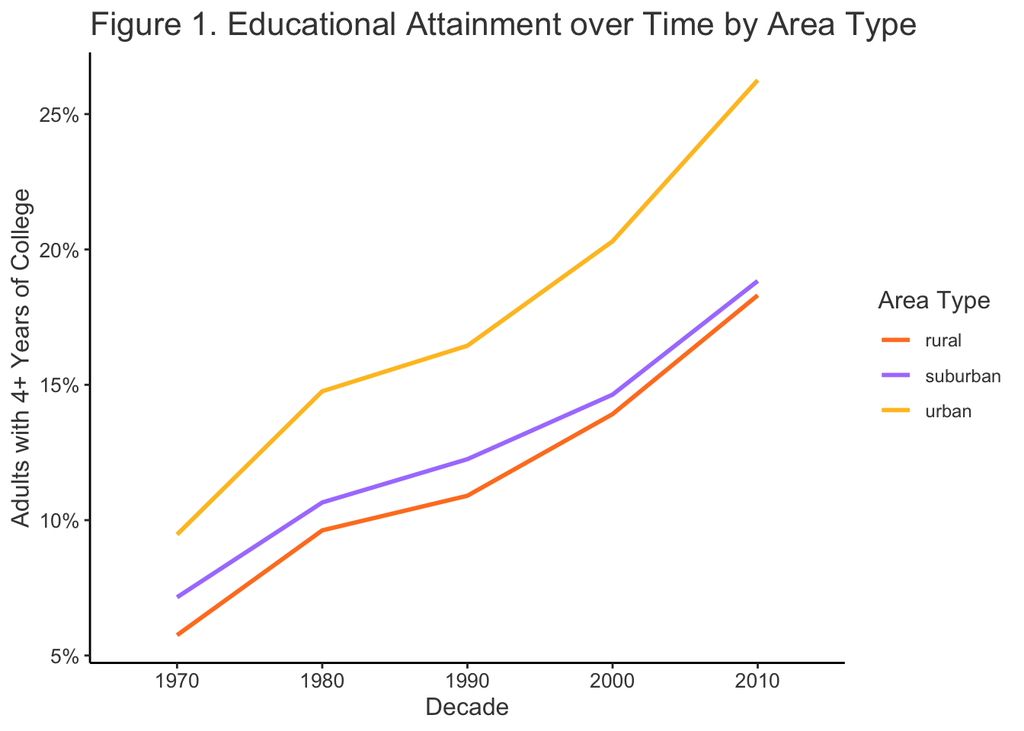

```r
# Include all code required to generate your visualization here.

ggplot(all_q1) +
  geom_line(aes(x = year,
                y = mean_education,
                color = ru_code,
                group = ru_code),
            size = 1) +
  labs(title = "Figure 1. Educational Attainment over Time by Area Type",
       x = "Decade",
       y = "Adults with 4+ Years of College") +
  theme_classic() +
  theme(axis.text.x = element_text(color = "gray26", size = 10),
        plot.title = element_text(color = "gray26", size = 16),
        axis.text.y = element_text(color = "gray26", size = 10),
        axis.title.x = element_text(color = "gray26", size = 12),
        axis.title.y = element_text(color = "gray26", size = 12),
        legend.text=element_text(color ="gray26", size = 9),
        legend.title = element_text(color ="gray26", size = 12)) +
   scale_color_manual(name = "Area Type", values=c("chocolate1", "mediumpurple1","goldenrod1")) +
  scale_y_continuous(labels = scales::label_number(suffix = "%", accuracy = 1))
```

**Q2: How is county educational attainment level related to county personal income over time?**

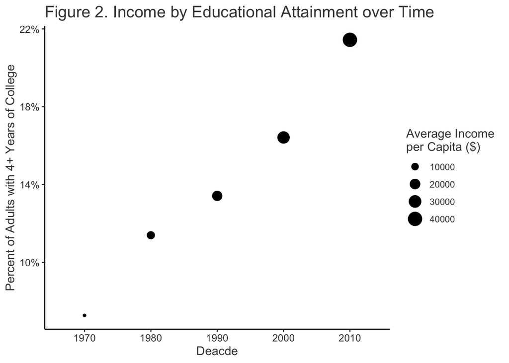

```r
# Include all code required to generate your visualization here.

ggplot(all_q2) +
  geom_point(aes(x = year,
                y = mean_education,
                size = mean_income)) +
  labs(title = "Figure 2. Income by Educational Attainment over Time ",
       x = "Deacde",
       y = "Percent of Adults with 4+ Years of College",
       size = "Average Income \nper Capita ($)") +
  theme_classic() +
  theme(axis.text.x = element_text(color = "gray26", size = 10),
        plot.title = element_text(color = "gray26", size = 16),
        axis.text.y = element_text(color = "gray26", size = 10),
        axis.title.x = element_text(color = "gray26", size = 12),
        axis.title.y = element_text(color = "gray26", size = 12),
        legend.text=element_text(color ="gray26", size = 9),
        legend.title = element_text(color ="gray26", size = 12)) +
  scale_y_continuous(labels = scales::label_comma(suffix = "%", accuracy = 1))
```

**Q3: How is county educational attainment level related to county personal income over time for different levels of urbanization?**

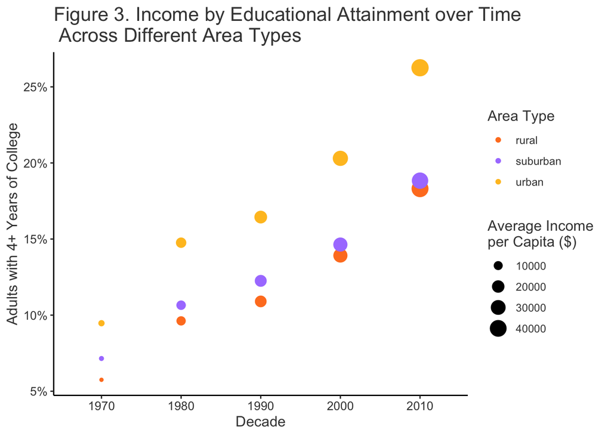

```r
# Include all code required to generate your visualization here.


ggplot(all_q1) +
  geom_point(aes(x = year,
                y = mean_education,
                size = mean_income,
                color = ru_code)) +
  labs(title = "Figure 3. Income by Educational Attainment over Time\n Across Different Area Types",
       x = "Decade",
       y = "Adults with 4+ Years of College",
       size = "Average Income \nper Capita ($)") +
  theme_classic() +
  theme(axis.text.x = element_text(color = "gray26", size = 10),
        plot.title = element_text(color = "gray26", size = 16),
        axis.text.y = element_text(color = "gray26", size = 10),
        axis.title.x = element_text(color = "gray26", size = 12),
        axis.title.y = element_text(color = "gray26", size = 12),
        legend.text=element_text(color ="gray26", size = 9),
        legend.title = element_text(color ="gray26", size = 12)) +
   scale_color_manual(name = "Area Type", values=c("chocolate1", "mediumpurple1","goldenrod1")) +
  scale_y_continuous(labels = scales::label_comma(suffix = "%", accuracy = 1))
```

**Discussion**

*Referencing your visualizations from above, answer the three research questions.*

Q1: How has educational attainment in counties changed over time for varying levels of urbanization?

Overall, the share of adults in U.S. counties with four or more years of college has increased overtime (Figure 1). That is, the average U.S. county in the 1970s had only ~5 - ~10% of adults with a bachelor’s degree or higher; by the 2010s, that percent had increased to ~17% - ~25%.

The share of adults in a county with 4+ years of college education, however, is highly dependent on the type of area the county is in. Across time, rural counties, as compared to suburban and urban ones, have the lowest share of college-educated adults. Urban counties, on the other hand, consistently have the highest percent of college-educated adults in each decade.

This is increasingly true from the 1980s and onward, as the gap between urban counties and suburban/rural counties has steadily increased over the decades.

Q2: How is county educational attainment level related to county personal income over time?

As evidenced by the size of the dots on the y-axis in Figure 2, there is a positive association between the share of college-educated adults in a county and that county’s average per-capita income. That is, the more highly educated the county is (the more the dot moves upward on the y-axis), the higher the income is (the larger the size of the dot). This trend is true across every decade from the 1970s to the 2010s, although with each sequential decade, both the college-attainment rate and income increase (the dot both moves up the y-axis and gets larger).

Q3: How is county educational attainment level related to county personal income over time for different levels of urbanization?

Surprisingly, Figure 3 shows that the temporal association between college-attainment levels and income is similar across the different county types. That is, although urban counties are more highly educated than non-urban ones, urban, suburban, and rural counties all have similar average per-capita incomes. This is evidenced in the size of the dots on the y-axis for each decade, which are all almost exactly the same. The one decade where a county’s area type seems to be most meaningful is the 1970s, where urban counties have both the highest share of college-educated adults and the highest per-capita income, followed by suburban and then rural counties. To be sure, in the 1970s, the size of the dot (representing income level) increases as the percent of adults with 4+ years of college increases, and urban counties have the highest rates of adults in that category.

This indicates that, in the 1980s and onward, a county’s area type is consequential for educational attainment, but not for income or for return of educational attainment on income. It should be noted, however, that the analysis in question considers data from the county-level, so these inferences cannot be made at the individual level.